# DATA607_Final_Project

Matheesha Thambeliyagodage

May 5, 2017

### **Project Objective**

- This project seeks to investigate the density of the correlation between Lung Cancer with Air Pollution, Tobacco Smoke, exposure to Radon and Radiation and Arsanic in drinking water.
- There are lots of lung cancer patient around the world who suffer with the lung cancer but still hard to identify a good course for the reason. Most geographical locations don’t have enough resources to measure the coursing risk factors but USA.
- There for I decided to use the data sets available in USA to find the correlation between the problem and risk factors.

**Lung Cancer statistics in the…**

```
##                                       Maximum Moderate Minimum
## Cities with Air Pollution             |   *   |   *    |   *
## Cities with Tobacco Smoke             |   *   |   *    |   *
## Cities with Radon and Radiation       |   *   |   *    |   *
## Cities with high Agriculture Industry |   *   |   *    |   *
```

**Risk Factor statistics in the…**

```
##                         Maximum Moderate Minimum
## Cities with Lung Cancer |   *   |   *    |   *
```

### **Data Sources**

- USA Population Statistics [List of U.S. states and territories by population](https://en.wikipedia.org/wiki/List_of_U.S._states_and_territories_by_population)  
  **Scrape HTML Table using rvest to data a frame**
- USA State Abbreviations and FIPS [USPS State Abbreviations and FIPS Codes](https://www.bls.gov/cew/cewedr10.htm)  
  **Scrape HTML Table using rvest to data a frame**
- Cities with Air Pollution Ranks [America’s Health Rankings](http://www.americashealthrankings.org/explore/2015-annual-report/measure/air/state/ALL)  
  **Downloaded Report Data from this web site**
- Cancer Statistics [United States Cancer Statistics (USCS)](https://www.cdc.gov/cancer/npcr/uscs/download_data.htm)  
  **Downloaded Report Data from this web site**
- Cities with Tobacco Smoke [Behavioral Risk Factor Data: Tobacco Use (2011 to present)](https://catalog.data.gov/dataset/behavioral-risk-factor-data-tobacco-use-2011-to-present)  
  **Downloaded Report Data ->**
- Cities with Radon and Radiation [EPA Map of Radon Zones including State Radon Information and Contacts](https://www.epa.gov/radon/find-information-about-local-radon-zones-and-state-contact-information)
- Cities with high Agriculture Industry for high Arsanic Levels [United States Cancer Statistics](https://nccd.cdc.gov/USCS/cancersbystateandregion.aspx?Year=2013&Variable1=California)

#### **Following process enter into the wikipedia.org and scrape the HTM table. The process also design to cleanse and filter the data in to datatframe …**

[figure not shown]

```r
library(rvest)
page <- read_html("http://en.wikipedia.org/wiki/List_of_U.S._states_and_territories_by_population")

pop_table <- page %>%
   html_node("table") %>%
   html_table(fill = TRUE)

pop_df <- as_data_frame(pop_table)

pop_df <- pop_df %>% mutate(StateName = `State or territory`) %>% mutate(Population = `Population estimate, July 1, 2016`)
popdf<- pop_df %>% select(StateName,Population)
popdf
```

```
## # A tibble: 59 × 2
##         StateName Population
##             <chr>      <chr>
## 1      California 39,250,017
## 2           Texas 27,862,596
## 3         Florida 20,612,439
## 4        New York 19,745,289
## 5    Pennsylvania 12,802,503
## 6        Illinois 12,801,539
## 7            Ohio 11,614,373
## 8         Georgia 10,310,371
## 9  North Carolina 10,146,788
## 10       Michigan  9,928,301
## # ... with 49 more rows
```

Back to the Menu<sub><sub><sub><sub><sub><sub><sub>~</sub></sub></sub></sub></sub></sub></sub>

===============================================================================================================

#### **Following process extract State Abbreviations and FIPS Codes . They will need in future data frame mappings …**

[figure not shown]

```r
library(rvest)

page <- read_html("https://www.bls.gov/cew/cewedr10.htm")

stat_table <- page %>%
   html_node("table") %>%
   html_table(fill = TRUE)

stat_df <- as_data_frame(stat_table,keep.rownames = TRUE)

#stat_df <- stat_df %>% mutate(StateName = `State or territory`) %>% mutate(Population = `Population estimate, July 1, 2016`)
statdf<- stat_df %>% select(X1,X2,X3,X4,X5,X6)
statdf <- filter(statdf,X1!= 'State')
statdf <- filter(statdf,X3!= 'State')
df1 <-  statdf%>% mutate(State = X1) %>% mutate(StateCode = X2) %>% mutate(StateID = X3)
df2 <-  statdf%>% mutate(State = X3) %>% mutate(StateCode = X4) %>% mutate(StateID = X5)
statdf1 <-  select(df1,State,StateCode,StateID)
statdf2 <-  select(df2,State,StateCode,StateID)

statedf<- rbind(statdf1, statdf2)
head(statedf)
```

```
## # A tibble: 6 × 3
##        State StateCode StateID
##        <chr>     <chr>   <chr>
## 1    Alabama        AL      01
## 2     Alaska        AK      02
## 3    Arizona        AZ      04
## 4   Arkansas        AR      05
## 5 California        CA      06
## 6   Colorado        CO      08
```

Back to the Menu<sub><sub><sub><sub><sub><sub><sub>~</sub></sub></sub></sub></sub></sub></sub>

===============================================================================================================

#### **Air Pollution Data files are stored in github and below process is loading them in to mysql. Then create separate data frames with the filtered values for analysis**

```r
#Loading airports.csv
airpo15_df <- read.csv("https://raw.githubusercontent.com/mathsanu/CUNY_MSDA/master/DATA607/FinalProject/data/2015SeniorRanks.csv", header=TRUE)
airpo16_df <- read.csv("https://raw.githubusercontent.com/mathsanu/CUNY_MSDA/master/DATA607/FinalProject/data/2016SeniorRanks.csv", header=TRUE)
```

### Connecting to MySQL database in the localhost.

```r
library('RMySQL')
#mydb = dbConnect(MySQL(), user='root', password='root', host='localhost', dbname="ourairports")
mydb = dbConnect(MySQL(), user='root', password='root', host='localhost')

# DROP the database if exists using RMySQL in R
dbSendQuery(mydb, "DROP DATABASE if exists 607finalprj;")
```

```
## <MySQLResult:2,0,0>
```

```r
# creating the database using RMySQL in R
dbSendQuery(mydb, "CREATE DATABASE 607finalprj;")
```

```
## <MySQLResult:2,0,1>
```

```r
mydb = dbConnect(MySQL(), user='root', password='root', host='localhost', dbname="607finalprj")
```

### Insert above record sets into MySQL

```r
# 1 ~~~airpo15_df~~~~~~~~~~~~~~~~~~~~~~~~~~~~~~~~~~~~~~~~~~~~~~~
# Create Table and Insert records from airpo15_df in MySql Database ("607finalprj")
dbSendQuery(mydb, "drop table if exists allcensus")
```

```
## <MySQLResult:122805272,1,0>
```

```r
dbWriteTable(mydb, value = airpo15_df, name = "allcensus", overwrite=TRUE, row.names=FALSE,add_id = TRUE)
```

```
## [1] TRUE
```

```r
# 1 ~~~airpo16_df~~~~~~~~~~~~~~~~~~~~~~~~~~~~~~~~~~~~~~~~~~~~~~~
# Insert records from airpo16_df  into MySql table ("allcensus")
dbWriteTable(mydb, 'allcensus', airpo16_df, row.names=F, append=T)
```

```
## [1] TRUE
```

**Creating an aggrigate Data fram from the data in mysql database**

```r
airp_df<-dbGetQuery(mydb,"SELECT Edition ,`Measure.Name`,    `allcensus`.`State.Name`,
    `allcensus`.`Rank`,
    `allcensus`.`Value`,
    `allcensus`.`Score`
FROM 607finalprj.allcensus
where `Measure.Name` = 'Air Pollution'
order by `Value`;")
head(airp_df,5)
```

```
##   Edition  Measure.Name   State.Name Rank Value Score
## 1    2015 Air Pollution      Wyoming    1   5.0 -2.00
## 2    2015 Air Pollution North Dakota    2   5.2 -2.00
## 3    2015 Air Pollution      Montana    3   5.7 -2.00
## 4    2015 Air Pollution       Alaska    4   6.0 -2.00
## 5    2015 Air Pollution      Vermont    5   6.2 -1.96
```

**According to the Air Pollution Ranks highest polluted States are**

```
##              Rank   Highest
## California   |   50 |   12.5
## Idaho        |   49 |   11.7
## Pennsylvania |   48 |   11.4
## Indiana      |   47 |   11.3
## Illinois     |   46 |   11.1
```

**Moderately polluted States are**

```
##                Rank   Moderate
## Wisconsin      |   30 |   9.1
## South Carolina |   29 |   9
## Mississippi    |   27 |   8.9
## Utah           |   26 |   8.6
## Connecticut    |   25 |   8.8
```

**Lowest polluted States are**

```
##              Rank  Moderate
## Vermont      |   5 |   6.2
## Alaska       |   4 |   6
## Montana      |   3 |   5.7
## North Dakota |   2 |   5.2
## Wyoming      |   1 |   5
```

Back to the Menu<sub><sub><sub><sub><sub><sub><sub>~</sub></sub></sub></sub></sub></sub></sub>

===============================================================================================================

#### **Cancer statistics join with above data frame “State Population” to calculate the deaths as a percentage of the population. Otherwise direct total deaths will not be a accurate variable**

```r
lungcancer_df <- read.csv("https://raw.githubusercontent.com/mathsanu/CUNY_MSDA/master/DATA607/FinalProject/data/LungCancer.csv", header=TRUE)

lungcancer_df <- filter(lungcancer_df,Leading.Cancer.Sites == 'Lung and Bronchus')
head(lungcancer_df,5)
```

```
##   Notes Leading.Cancer.Sites Leading.Cancer.Sites.Code        State
## 1          Lung and Bronchus                     22030   California
## 2          Lung and Bronchus                     22030      Florida
## 3          Lung and Bronchus                     22030        Texas
## 4          Lung and Bronchus                     22030     New York
## 5          Lung and Bronchus                     22030 Pennsylvania
##   State.Code Deaths
## 1          6  12464
## 2         12  11915
## 3         48   9439
## 4         36   9074
## 5         42   7536
```

```r
# Join DF , calculating deathratio and deathrank

lc_df <- left_join(lungcancer_df,popdf, by=c("State" = "StateName") )
lc_df1<- lc_df %>% mutate(deathratio = (Deaths/as.numeric(gsub(",", "",Population)) ) * 10000) %>% arrange(desc(deathratio))%>%mutate(deathrank=row_number())

head(lc_df1,5)
```

```
##   Notes Leading.Cancer.Sites Leading.Cancer.Sites.Code         State
## 1          Lung and Bronchus                     22030      Kentucky
## 2          Lung and Bronchus                     22030 West Virginia
## 3          Lung and Bronchus                     22030         Maine
## 4          Lung and Bronchus                     22030      Arkansas
## 5          Lung and Bronchus                     22030    Washington
##   State.Code Deaths Population deathratio deathrank
## 1         21   3559  4,436,974   8.021232         1
## 2         54   1437  1,831,102   7.847733         2
## 3         23   1025  1,331,479   7.698206         3
## 4          5   2168  2,988,248   7.255087         4
## 5         53   3020  4,288,000   7.042910         5
```

```r
ls(lc_df1)
```

```
## [1] "deathrank"                 "deathratio"
## [3] "Deaths"                    "Leading.Cancer.Sites"
## [5] "Leading.Cancer.Sites.Code" "Notes"
## [7] "Population"                "State"
## [9] "State.Code"
```

```r
lc_df1 %>% filter(deathrank < 6)
```

```
##   Notes Leading.Cancer.Sites Leading.Cancer.Sites.Code         State
## 1          Lung and Bronchus                     22030      Kentucky
## 2          Lung and Bronchus                     22030 West Virginia
## 3          Lung and Bronchus                     22030         Maine
## 4          Lung and Bronchus                     22030      Arkansas
## 5          Lung and Bronchus                     22030    Washington
##   State.Code Deaths Population deathratio deathrank
## 1         21   3559  4,436,974   8.021232         1
## 2         54   1437  1,831,102   7.847733         2
## 3         23   1025  1,331,479   7.698206         3
## 4          5   2168  2,988,248   7.255087         4
## 5         53   3020  4,288,000   7.042910         5
```

```r
lc_df1 %>% filter(deathrank > 45)
```

```
##   Notes Leading.Cancer.Sites Leading.Cancer.Sites.Code      State
## 1          Lung and Bronchus                     22030     Alaska
## 2          Lung and Bronchus                     22030 New Mexico
## 3          Lung and Bronchus                     22030      Texas
## 4          Lung and Bronchus                     22030 California
## 5          Lung and Bronchus                     22030   Colorado
## 6          Lung and Bronchus                     22030       Utah
##   State.Code Deaths Population deathratio deathrank
## 1          2    273    741,894   3.679771        46
## 2         35    736  2,081,015   3.536736        47
## 3         48   9439 27,862,596   3.387696        48
## 4          6  12464 39,250,017   3.175540        49
## 5          8   1561  5,540,545   2.817412        50
## 6         49    437  3,051,217   1.432215        51
```

[figure not shown]

```r
library(ggplot2)
ggplot(lc_df1, aes(fill=deathratio, y=deathratio, x=State)) + ggtitle("Death Ratio in each State ") +   geom_bar( stat="identity") + theme(axis.text.x = element_text(angle = 90, hjust = 1)) + geom_point()
```

#### **Joining the Lung Cancer Death datafram and Air Polition datafrm by State to fingd the correlation**

airp_df

```r
# Join DF , calculating deathratio and deathrank
# head(lc_df1)
# head(airp_df)

lcap_df <- left_join(lc_df1,airp_df, by=c("State" = "State.Name") )
# lc_df1<- lc_df %>% mutate(deathratio = (Deaths/as.numeric(gsub(",", "",Population)) ) * 10000) %>% arrange(desc(deathratio))%>%mutate(deathrank=row_number())

head(lcap_df,5)
```

```
##   Notes Leading.Cancer.Sites Leading.Cancer.Sites.Code         State
## 1          Lung and Bronchus                     22030      Kentucky
## 2          Lung and Bronchus                     22030 West Virginia
## 3          Lung and Bronchus                     22030         Maine
## 4          Lung and Bronchus                     22030      Arkansas
## 5          Lung and Bronchus                     22030    Washington
##   State.Code Deaths Population deathratio deathrank Edition  Measure.Name
## 1         21   3559  4,436,974   8.021232         1    2015 Air Pollution
## 2         54   1437  1,831,102   7.847733         2    2015 Air Pollution
## 3         23   1025  1,331,479   7.698206         3    2015 Air Pollution
## 4          5   2168  2,988,248   7.255087         4    2015 Air Pollution
## 5         53   3020  4,288,000   7.042910         5    2015 Air Pollution
##   Rank Value Score
## 1   44  10.1  0.36
## 2   33   9.4 -0.06
## 3   13   7.4 -1.25
## 4   37   9.7  0.12
## 5   17   8.0 -0.89
```

```r
summary(lcap_df)
```

```
##                                                                                                                        Notes
##                                                                                                                           :51
##  ---                                                                                                                      : 0
##  1. 'Suppressed' is displayed for data values when they must not be provided in order to protect personal privacy. Data is: 0
##  1. Totals are not available for these results due to suppression constraints. More Information:                          : 0
##  2. 'Not Applicable' is displayed for all data values when gender-specific cancers are combined with the wrong sex. More  : 0
##  2. Rows with suppressed Deaths are hidden. Use Quick Options above to show suppressed rows.                              : 0
##  (Other)                                                                                                                  : 0
##                      Leading.Cancer.Sites Leading.Cancer.Sites.Code
##  Lung and Bronchus             :51        22030      :51
##                                : 0                   : 0
##  Brain and Other Nervous System: 0        20010-20100: 0
##  Breast                        : 0        21010      : 0
##  Cervix Uteri                  : 0        21020      : 0
##  Colon and Rectum              : 0        21041-21052: 0
##  (Other)                       : 0        (Other)    : 0
##     State             State.Code        Deaths         Population
##  Length:51          Min.   : 1.00   Min.   :  230.0   Length:51
##  Class :character   1st Qu.:16.50   1st Qu.:  713.5   Class :character
##  Mode  :character   Median :29.00   Median : 2391.0   Mode  :character
##                     Mean   :28.96   Mean   : 3062.3
##                     3rd Qu.:41.50   3rd Qu.: 4003.0
##                     Max.   :56.00   Max.   :12464.0
##
##    deathratio      deathrank       Edition     Measure.Name
##  Min.   :1.432   Min.   : 1.0   Min.   :2015   Length:51
##  1st Qu.:4.448   1st Qu.:13.5   1st Qu.:2015   Class :character
##  Median :4.974   Median :26.0   Median :2015   Mode  :character
##  Mean   :5.158   Mean   :26.0   Mean   :2015
##  3rd Qu.:5.977   3rd Qu.:38.5   3rd Qu.:2015
##  Max.   :8.021   Max.   :51.0   Max.   :2015
##
##       Rank           Value            Score
##  Min.   : 1.00   Min.   : 5.000   Min.   :-2.0000
##  1st Qu.:13.25   1st Qu.: 7.500   1st Qu.:-1.2200
##  Median :24.00   Median : 8.800   Median :-0.4200
##  Mean   :25.10   Mean   : 8.669   Mean   :-0.4922
##  3rd Qu.:37.00   3rd Qu.: 9.700   3rd Qu.: 0.1200
##  Max.   :50.00   Max.   :12.500   Max.   : 1.7800
##  NA's   :1                        NA's   :1
```

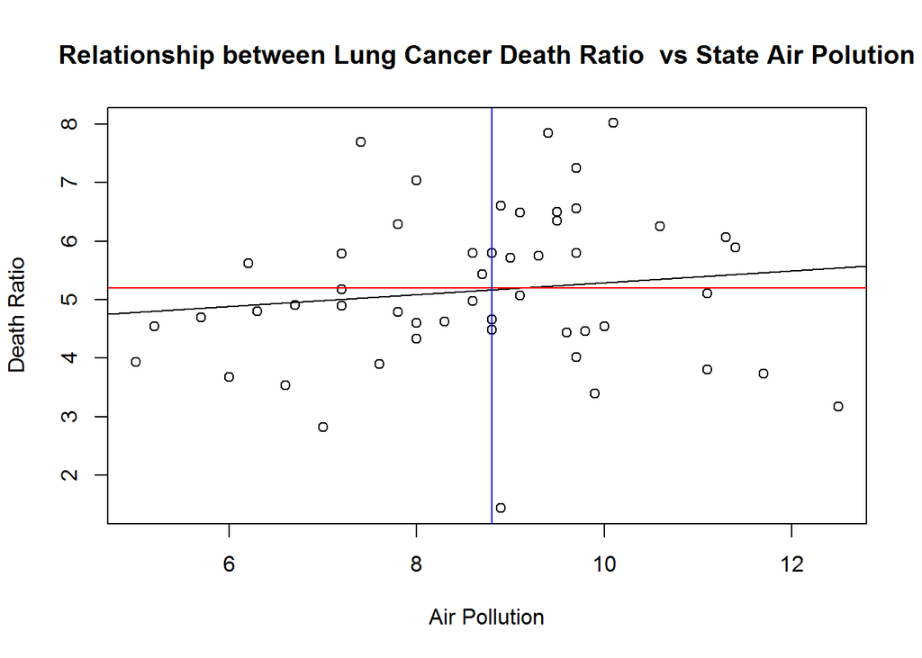

```r
library(ggplot2)
lcap_df.lm1  <- lm(deathratio ~ Value, data = lcap_df)
plot(lcap_df$deathratio ~ lcap_df$Value, main = "Relationship between Lung Cancer Death Ratio  vs State Air Polution",xlab='Air Pollution',ylab='Death Ratio')
 abline(lcap_df.lm1 )
 abline(h=5.197,col = "red")
 abline(v= 8.800 ,col = "blue" )
```

```r
summary(lcap_df.lm1)
```

```
##
## Call:
## lm(formula = deathratio ~ Value, data = lcap_df)
##
## Residuals:
##     Min      1Q  Median      3Q     Max
## -3.7489 -0.7846 -0.1231  0.7414  2.7189
##
## Coefficients:
##             Estimate Std. Error t value Pr(>|t|)
## (Intercept)   4.2814     0.9823   4.358  6.7e-05 ***
## Value         0.1011     0.1112   0.909    0.368
## ---
## Signif. codes:  0 '***' 0.001 '**' 0.01 '*' 0.05 '.' 0.1 ' ' 1
##
## Residual standard error: 1.339 on 49 degrees of freedom
## Multiple R-squared:  0.01657,    Adjusted R-squared:  -0.003496
## F-statistic: 0.8258 on 1 and 49 DF,  p-value: 0.3679
```

Back to the Menu<sub><sub><sub><sub><sub><sub><sub>~</sub></sub></sub></sub></sub></sub></sub>